# Keras Multivariate(Parkinsons)/Binary Classification (Breast Cancer)

```r
#https://github.com/statsmaths/kerasR
```

```r
#if(!require(bayesian_first_aid)){devtools::install_github("rasmusab/bayesian_first_aid")}
if(!require(easypackages)){install.packages("easypackages")}
library(easypackages)
packages("dplyr","dummies", "reticulate", "tensorflow", "keras", prompt = FALSE)

setwd("~/GitHub/DeepLearning")
```

# Multivariate - Parkinsons

This code performs multivariate regression using Tensorflow and keras on the advent of Parkinson disease through sound recordings see Parkinson Speech Dataset with Multiple Types of Sound Recordings Data Set. The clinician’s motorUPDRS score has to be predicted from the set of features.

## Data

```r
# Download the Parkinson's data from UCI Machine Learning repository
dataset <- read.csv("D:/LargeData/parkinsons_updrs.data")

# Set the column names
names(dataset) <- c("subject","age", "sex", "test_time","motor_UPDRS","total_UPDRS","Jitter","Jitter.Abs",
                 "Jitter.RAP","Jitter.PPQ5","Jitter.DDP","Shimmer", "Shimmer.dB", "Shimmer.APQ3",
                 "Shimmer.APQ5","Shimmer.APQ11","Shimmer.DDA", "NHR","HNR", "RPDE", "DFA","PPE")

# Remove the column 'subject' as it is not relevant to analysis
dataset1 <- subset(dataset, select = -c(subject))

# Make the column 'sex' as a factor for using dummies
dataset1$sex = as.factor(dataset1$sex)
# Add dummy variables for categorical variable 'sex'
dataset2 <- dummy.data.frame(dataset1, sep = ".")

dataset3 <- na.omit(dataset2)
```

Split the data as training and test in 80/20

```r
## Split data 80% training and 20% test
sample_size <- floor(0.8 * nrow(dataset3))

## set the seed to make your partition reproducible
set.seed(12)
train_index <- sample(seq_len(nrow(dataset3)), size = sample_size)

train_dataset <- dataset3[train_index, ]
test_dataset <- dataset3[-train_index, ]

train_data <- train_dataset %>% select(sex.0, sex.1, age, test_time, Jitter, Jitter.Abs, Jitter.PPQ5, Jitter.DDP, Shimmer,
                                       Shimmer.dB, Shimmer.APQ3, Shimmer.APQ11, Shimmer.DDA, NHR, HNR, RPDE, DFA, PPE)

train_labels <- select(train_dataset, motor_UPDRS)
test_data <- test_dataset %>% select(sex.0, sex.1,age, test_time, Jitter, Jitter.Abs, Jitter.PPQ5, Jitter.DDP, Shimmer,
                                     Shimmer.dB, Shimmer.APQ3, Shimmer.APQ11, Shimmer.DDA, NHR, HNR, RPDE, DFA, PPE)
test_labels <- select(test_dataset,motor_UPDRS)
```

Normalize the data

```r
 # Normalize the data by subtracting the mean and dividing by the standard deviation
normalize<-function(x) {y <- (x - mean(x)) / sd(x)
return(y)}

normalized_train_data <-apply(train_data, 2, normalize)
# Convert to matrix
train_labels <- as.matrix(train_labels)
normalized_test_data <- apply(test_data, 2, normalize)
test_labels <- as.matrix(test_labels)
```

## Create Model

```r
model <- keras_model_sequential()
model %>%
  layer_dense(units = 6, activation = 'relu',
             input_shape = dim(normalized_train_data)[2]) %>%
  layer_dense(units = 9, activation = 'relu') %>%
  layer_dense(units = 6, activation = 'relu') %>%
  layer_dense(units = 1)

# Set the metrics required to be Mean Absolute Error and Mean Squared Error.For regression, the loss is
# mean_squared_error
model %>% compile(loss = 'mean_squared_error', optimizer = optimizer_rmsprop(), metrics = c('mean_absolute_error','mean_squared_error'))

# Fit the model
# Use the test data for validation
history <- model %>% fit(normalized_train_data, train_labels, epochs = 30, batch_size = 128,
                          validation_data = list(normalized_test_data,test_labels))
```

## Plot Performance

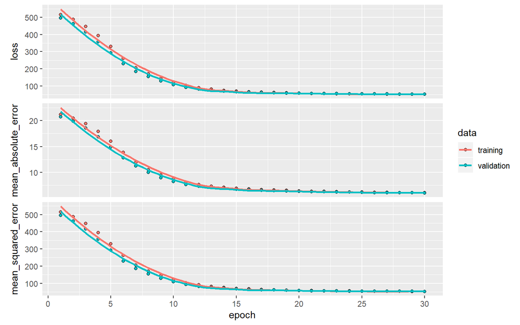

```r
plot(history)
```

# Binary Classification

This is a simple binary classification problem from UCI Machine Learning repository and deals with data on Breast cancer from the Univ. of Wisconsin Breast Cancer Wisconsin (Diagnostic) Data Sethttps://archive.ics.uci.edu/ml/datasets/Breast+Cancer+Wisconsin+%28Diagnostic%29

## Data

```r
# Read the data for Breast cancer (Wisconsin)
dataset <- read.csv("https://archive.ics.uci.edu/ml/machine-learning-databases/breast-cancer-wisconsin/breast-cancer-wisconsin.data")

# Rename the columns
names(dataset) <- c("id","thickness", "cellsize", "cellshape", "adhesion", "epicellsize", "barenuclei", "chromatin",
                    "normalnucleoli","mitoses","class")

# Remove the columns id and class
dataset1 <- subset(dataset, select = -c(id, class))
dataset2 <- na.omit(dataset1)

# Convert the column to numeric
dataset2$barenuclei <- as.numeric(dataset2$barenuclei)
```

Normalize the data

```r
train_data <-apply(dataset2, 2, normalize)
train_labels <- as.matrix(select(dataset, class))

# Set the target variables as 0 or 1 as it binary classification
train_labels[train_labels == 2, ] = 0
train_labels[train_labels == 4, ] = 1
```

## Create Model

```r
model <- keras_model_sequential()
model %>%
  layer_dense(units = 6, activation = 'relu', input_shape = dim(train_data)[2]) %>%
  layer_dense(units = 9, activation = 'relu') %>%
  layer_dense(units = 6, activation = 'relu') %>%
  layer_dense(units = 1)

# Since this is a binary classification we use binary cross entropy
model %>% compile(loss = 'binary_crossentropy', optimizer = optimizer_rmsprop(), metrics = c('accuracy'))  # Metrics is accuracy
```

Fit the model. Use 20% of data for validation

```r
history <- model %>% fit(train_data, train_labels, epochs = 30, batch_size = 128, validation_split = 0.2)
```

## Plot Performance

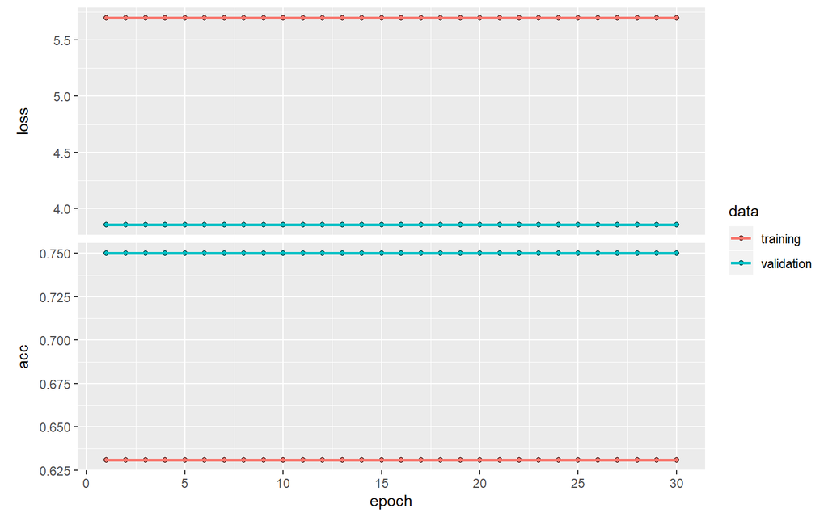

```r
plot(history)
```

# MNIST

## Data

```r
mnist <- dataset_mnist()
x_train <- mnist$train$x
y_train <- mnist$train$y
x_test <- mnist$test$x
y_test <- mnist$test$y
```

Reshape and rescale

```r
# Reshape the array
x_train <- array_reshape(x_train, c(nrow(x_train), 784))
x_test <- array_reshape(x_test, c(nrow(x_test), 784))
# Rescale
x_train <- x_train / 255
x_test <- x_test / 255
```

Convert out put to One Hot encoded format

```r
y_train <- to_categorical(y_train, 10)
y_test <- to_categorical(y_test, 10)
```

## Create Model

Use the softmax activation for recognizing 10 digits and categorical cross entropy for loss

```r
model <- keras_model_sequential()
model %>%
  layer_dense(units = 256, activation = 'relu', input_shape = c(784)) %>%
  layer_dense(units = 128, activation = 'relu') %>%
  layer_dense(units = 10, activation = 'softmax') # Use softmax

model %>% compile(loss = 'categorical_crossentropy', optimizer = optimizer_rmsprop(), metrics = c('accuracy'))
```

Fit the model Note: A smaller number of epochs has been used. For better performance increase number of epochs

```r
history <- model %>% fit(x_train, y_train, epochs = 20, batch_size = 128, validation_data = list(x_test,y_test))
```

## Plot Performance

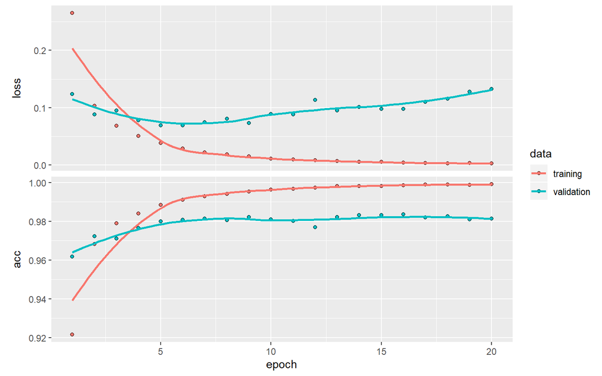

```r
plot(history)
```